# lab7

Yuchen Song_201830360498 - Xuewen Wang_201830120252

2021/10/27

### Data Loading

```r
load(url("http://www.stat.duke.edu/~cr173/Sta102_Sp16/Lab/nc.RData"))
```

### Ex1

```r
dim(nc)
```

```
## [1] 1000   13
```

Each case represent some information of a birth of babies, including itself and its parents, and there are 1,000 cases in total.

### Ex2

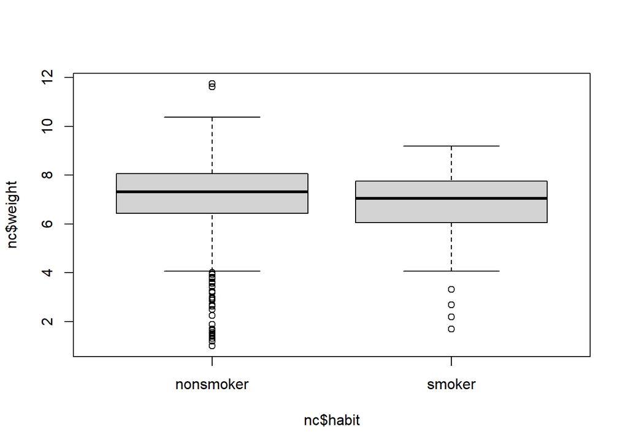

```r
boxplot(nc$weight~nc$habit)
```

The plot highlights that if the mother has a smoking habit, then the child is tend to have a lower weight.

### Ex3

$H_0: \mu_{nonsmoker} - \mu_{smoker} = 0$  
There is no difference between the weight of babies of non-smoking and smoking mothers.

$H_A: \mu_{nonsmoker} - \mu_{smoker} \neq 0$  
There is some difference between the weight of babies of non-smoking and smoking mothers.

### Ex4

```r
load(url("http://www.stat.duke.edu/~cr173/Sta102_Sp16/Lab/inference.RData"))
inference(y = nc$weight, x = nc$habit, est = "mean", type = "ci", null = 0, alternative = "twosided", method = "theoretical")
```

```
## Response variable: numerical, Explanatory variable: categorical
## Difference between two means
## Summary statistics:
## n_nonsmoker = 873, mean_nonsmoker = 7.1443, sd_nonsmoker = 1.5187
## n_smoker = 126, mean_smoker = 6.8287, sd_smoker = 1.3862
```

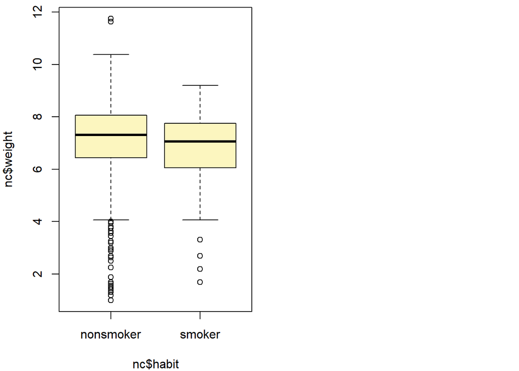

```
## Observed difference between means (nonsmoker-smoker) = 0.3155
## Standard error = 0.1338
## 95 % Confidence interval = ( 0.0534 , 0.5777 )
```

This interval means that we have 95% confidence that our interval would capture the difference between means of baby weight of nonsmoker and smoker mother.

### Ex5

```r
inference(y = nc$weeks, est = "mean", type = "ci", null = 0, alternative = "twosided", method = "theoretical")
```

```
## Single mean
## Summary statistics:
```

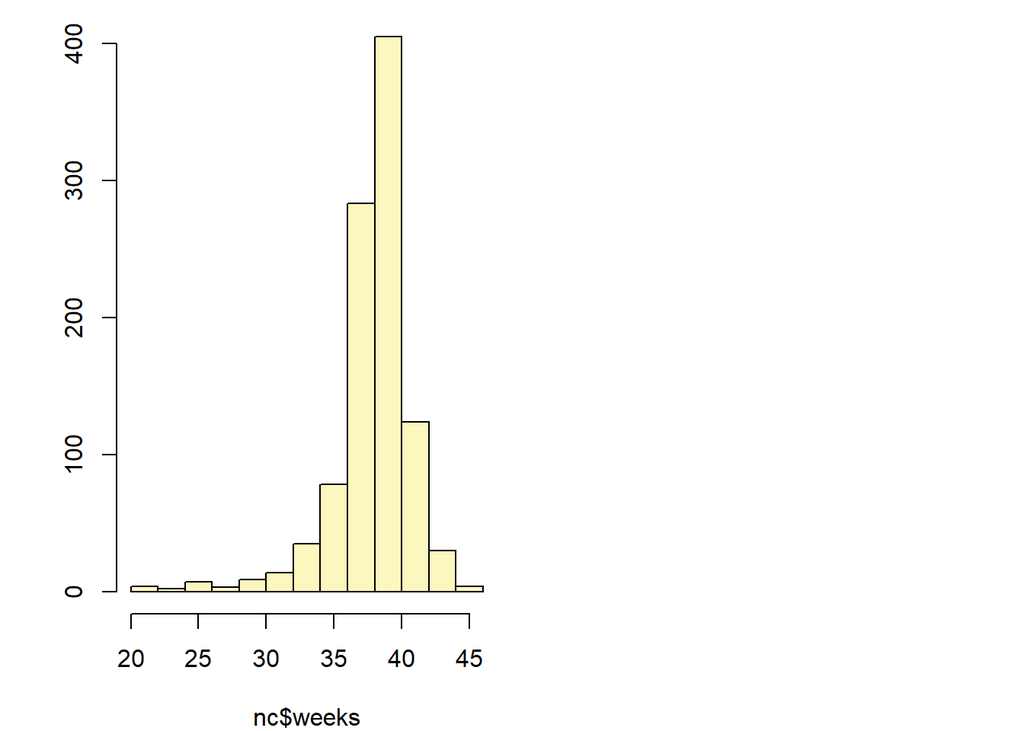

```
## mean = 38.3347 ;  sd = 2.9316 ;  n = 998
## Standard error = 0.0928
## 95 % Confidence interval = ( 38.1528 , 38.5165 )
```

We have 95% confidence that the average length of pregnancies(in weeks) is in the interval of (38.1528, 38.5165).

### Ex6

We expect a 90% confidence interval to be narrower.

```r
inference(y = nc$weeks, est = "mean", type = "ci", null = 0, alternative = "twosided", method = "theoretical",conflevel = 0.90)
```

```
## Single mean
## Summary statistics:
```

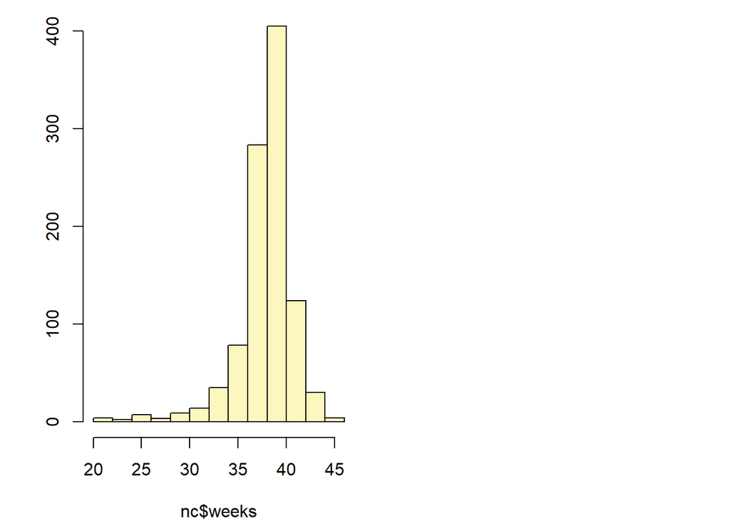

```
## mean = 38.3347 ;  sd = 2.9316 ;  n = 998
## Standard error = 0.0928
## 90 % Confidence interval = ( 38.182 , 38.4873 )
```

### Ex7

```r
inference(y = nc$weight, x = nc$mature, est = "mean", type = "ht", null = 0, alternative = "twosided", method = "theoretical")
```

```
## Response variable: numerical, Explanatory variable: categorical
## Difference between two means
## Summary statistics:
## n_mature mom = 133, mean_mature mom = 7.1256, sd_mature mom = 1.6591
## n_younger mom = 867, mean_younger mom = 7.0972, sd_younger mom = 1.4855
```

```
## Observed difference between means (mature mom-younger mom) = 0.0283
## H0: mu_mature mom - mu_younger mom = 0
## HA: mu_mature mom - mu_younger mom != 0
## Standard error = 0.152
## Test statistic: Z =  0.186
## p-value =  0.8526
```

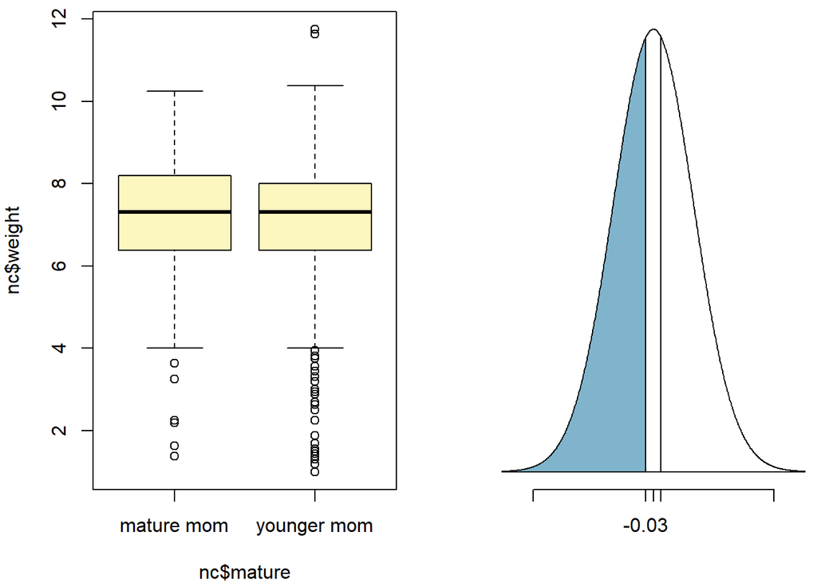

P-value is the probability that assuming the null hypothesis(no difference between the weight of babies of young mother and mature mother) is true, the test difference is larger than the observed difference(0.0283).

### Ex8

```r
by(nc$mage, nc$mature, max)
```

```
## nc$mature: mature mom
## [1] 50
## ------------------------------------------------------------
## nc$mature: younger mom
## [1] 34
```

```r
by(nc$mage, nc$mature, min)
```

```
## nc$mature: mature mom
## [1] 35
## ------------------------------------------------------------
## nc$mature: younger mom
## [1] 13
```

We would expect the cutoff age to be 34(or 35). In our method, we use the “by” function with the parameter of “max” and “min” to gather the information of the maximum and minimum age of each group. The cutoff age must be in the interval between the maximum age of young mother and the minimum age of the mature mother.

### Ex9

```r
inference(y = nc$mage, x = nc$premie, est = "mean", type = "ht", null = 0, alternative = "twosided", method = "theoretical")
```

```
## Response variable: numerical, Explanatory variable: categorical
## Difference between two means
## Summary statistics:
## n_full term = 846, mean_full term = 27, sd_full term = 6.1444
## n_premie = 152, mean_premie = 26.875, sd_premie = 6.533
```

```
## Observed difference between means (full term-premie) = 0.125
## H0: mu_full term - mu_premie = 0
## HA: mu_full term - mu_premie != 0
## Standard error = 0.57
## Test statistic: Z =  0.219
## p-value =  0.8266
```

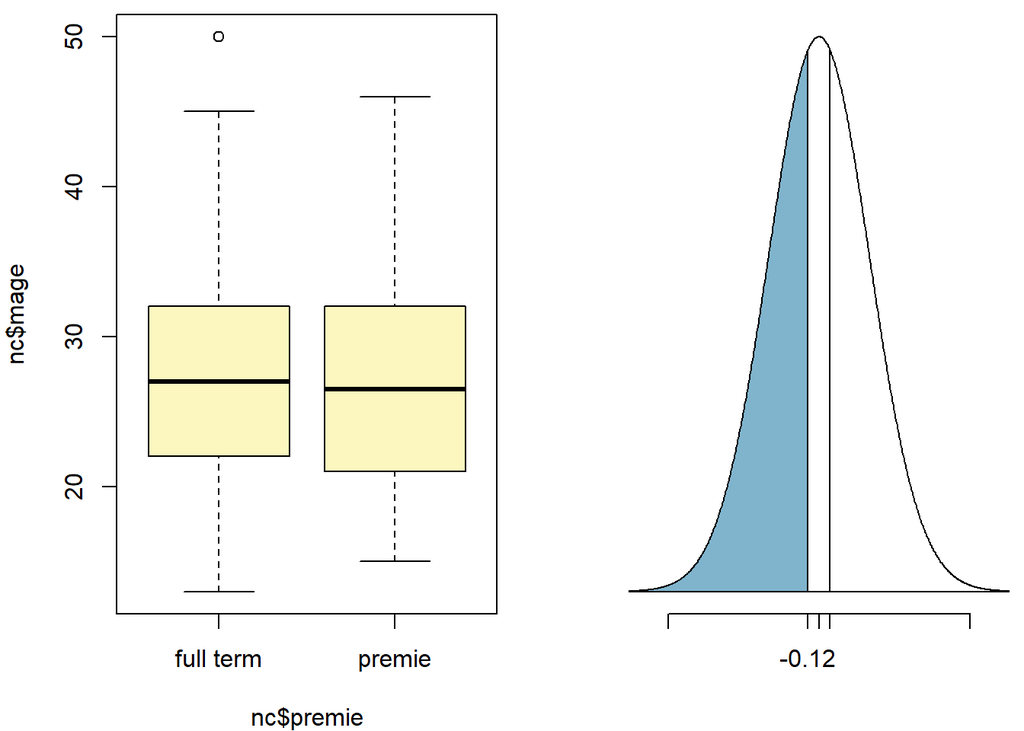

The p-value is high(0.8266), so we don’t have enough confidence to reject H0, that is to say, there is no significant difference between the average age of mothers born premature and full-term.

### Ex10

```r
inference(y = nc$weight, x = nc$gender, est = "mean", type = "ci", null = 0, alternative = "twosided", method = "theoretical", order = c("male","female"))
```

```
## Response variable: numerical, Explanatory variable: categorical
## Difference between two means
## Summary statistics:
## n_male = 497, mean_male = 7.3015, sd_male = 1.5168
## n_female = 503, mean_female = 6.9029, sd_female = 1.4759
```

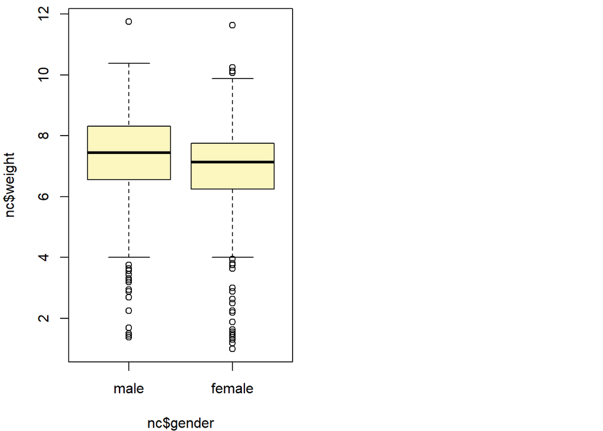

```
## Observed difference between means (male-female) = 0.3986
## Standard error = 0.0947
## 95 % Confidence interval = ( 0.2131 , 0.5841 )
```

The 95% confidence interval for the difference between the average birth weight of baby boys and girls is (0.2131,0.5841).